# Clustering texts

K-means and Hierarchical clustering

Akos Mate

2019 October

```r
library(quanteda)
library(quanteda.corpora)

library(gridExtra)

library(factoextra)
library(ggplot2)
library(ggdendro)
```

```r
set.seed(042)
```

# 1 Clustering texts

## 1.1 Text similarity refresher

(This section is from Pablo Barbera’s LSE course materials. For links see the course repo description)

```r
docs <- c("this is document one", "this is document two")
(doc_dfm <- dfm(docs))
```

```
#> Document-feature matrix of: 2 documents, 5 features (20.0% sparse).
#> 2 x 5 sparse Matrix of class "dfm"
#>        features
#> docs    this is document one two
#>   text1    1  1        1   1   0
#>   text2    1  1        1   0   1
```

Calculate distance and similarity with the use of the Eucledian distance and cosine similarity

Euclidean distrance:

```r
textstat_dist(doc_dfm, method="euclidean")
```

```
#> textstat_dist object; method = "euclidean"
#>       text1 text2
#> text1     0  1.41
#> text2  1.41     0
```

Remember: $d_2(X_i, X_j)=(\sum(X_{i,k}-X_{j,k})^2)^{1/2}$

The distances we want to compute

```r
(d1 <- as.numeric(doc_dfm[1,]))
```

```
#> [1] 1 1 1 1 0
```

```r
(d2 <- as.numeric(doc_dfm[2,]))
```

```
#> [1] 1 1 1 0 1
```

Doing it by hand

```r
sqrt(sum((d1 - d2)^2))
```

```
#> [1] 1.414214
```

Important: Euclidean distance measures the *distance* of the documents. If we want to express similarity with this we need to formulate it as (1-distance) = similarity.

Cosine similarity

```r
textstat_simil(doc_dfm, method="cosine")
```

```
#> textstat_simil object; method = "cosine"
#>       text1 text2
#> text1  1.00  0.75
#> text2  0.75  1.00
```

Cosine similarity is computed as: $\frac{\sum A*B}{\sqrt{\sum A^2} * \sqrt{\sum B^2}}$

```r
sum(d1 * d2) / (sqrt(sum(d1^2)) *  sqrt(sum(d2^2)))
```

```
#> [1] 0.75
```

## 1.2 Clustering texts

We use the US presidents’ State of the Union speeches to try and cluster them with K-means and hierarchical clustering.

```r
sotu <- corpus_subset(data_corpus_sotu, Date >= "1990-01-01")

summary(sotu, 5)
```

```
#> Corpus consisting of 30 documents, showing 5 documents:
#>
#>          Text Types Tokens Sentences  FirstName President       Date
#>     Bush-1990  1206   4354       198     George      Bush 1990-01-31
#>     Bush-1991  1297   4493       226     George      Bush 1991-01-29
#>     Bush-1992  1493   5750       320     George      Bush 1992-01-28
#>  Clinton-1993  1561   7681       292 William J.   Clinton 1993-02-17
#>  Clinton-1994  1762   8267       399 William J.   Clinton 1994-01-25
#>  delivery  type      party
#>    spoken  SOTU Republican
#>    spoken  SOTU Republican
#>    spoken  SOTU Republican
#>    spoken other Democratic
#>    spoken  SOTU Democratic
#>
#> Source: http://www.presidency.ucsb.edu/sou.php
#> Created: Mon Feb 11 11:46:24 2019
#> Notes:
```

```r
ndoc(sotu)
```

```
#> [1] 30
```

Let’s do the usual steps and create a dfm.

```r
sotu_dfm <- dfm(sotu, remove_punct = TRUE, remove_numbers = TRUE,
                stem = TRUE, remove = stopwords("english")) %>%
    dfm_trim(min_docfreq = 3) %>%
    dfm_weight("prop")

sotu_dfm
```

```
#> Document-feature matrix of: 30 documents, 2,813 features (63.9% sparse).
```

The K-means clustering happens with the `kmeans` function which is built in the base R toolkit. We try first with `centers = 2` to see if we can get a republican democrat divide.

```r
sotu_k <- kmeans(sotu_dfm, centers = 2)

table(sotu_k$cluster)
```

```
#>
#>  1  2
#> 20 10
```

Seems OK.

```r
head(docvars(sotu)$President[sotu_k$cluster == 1])
```

```
#> [1] "Bush"    "Clinton" "Clinton" "Clinton" "Bush"    "Bush"
```

```r
head(docvars(sotu)$President[sotu_k$cluster == 2])
```

```
#> [1] "Bush"    "Bush"    "Clinton" "Clinton" "Clinton" "Clinton"
```

We can investigate the feature level as well.

```r
head(textstat_keyness(sotu_dfm, target = sotu_k$cluster == 1), n = 15)
```

```
#>        feature        chi2         p   n_target  n_reference
#> 1       energi 0.014698251 0.9035038 0.04995263 0.0049142566
#> 2    terrorist 0.014674377 0.9035819 0.05054256 0.0050869467
#> 3        iraqi 0.012671705 0.9103725 0.02666689 0.0002742732
#> 4       health 0.010258127 0.9193263 0.07961163 0.0175215365
#> 5         iraq 0.009176820 0.9236828 0.04075996 0.0057784101
#> 6          job 0.009052308 0.9242008 0.12496180 0.0355956189
#> 7           al 0.008802223 0.9252520 0.01931491 0.0003559986
#> 8  afghanistan 0.007375502 0.9315612 0.02118872 0.0014589398
#> 9        qaida 0.007261222 0.9320922 0.01451542 0.0000000000
#> 10        busi 0.006544769 0.9355217 0.06820676 0.0173908374
#> 11         tax 0.006427982 0.9360983 0.09758419 0.0286890418
#> 12     economi 0.006413280 0.9361713 0.07535025 0.0201989664
#> 13         oil 0.006130822 0.9375898 0.01628899 0.0008898403
#> 14       spend 0.005947644 0.9385273 0.04184030 0.0086740233
#> 15    recoveri 0.005628720 0.9401950 0.01318961 0.0004096682
```

```r
head(textstat_keyness(sotu_dfm, target = sotu_k$cluster == 2), n = 15)
```

```
#>      feature        chi2         p    n_target  n_reference
#> 1      thank 0.029321570 0.8640387 0.045348592 0.0260616486
#> 2    centuri 0.019772577 0.8881741 0.032058648 0.0191535609
#> 3       21st 0.018053652 0.8931148 0.016316651 0.0049393702
#> 4   challeng 0.017763435 0.8939723 0.036175224 0.0255646531
#> 5  communiti 0.013168066 0.9086415 0.041414674 0.0373453942
#> 6     balanc 0.010189056 0.9195974 0.012651598 0.0058775480
#> 7   children 0.009958563 0.9205090 0.052556773 0.0582270158
#> 8       hero 0.008629288 0.9259878 0.007553810 0.0021611275
#> 9     beauti 0.008321813 0.9273146 0.004966583 0.0004442470
#> 10      must 0.007920818 0.9290827 0.093777687 0.1284430740
#> 11      gang 0.007769550 0.9297614 0.006903787 0.0020281984
#> 12     enabl 0.007480282 0.9310780 0.004409379 0.0003665689
#> 13    soviet 0.007266283 0.9320686 0.006897726 0.0022605858
#> 14     first 0.007163489 0.9325497 0.039087560 0.0437687057
#> 15      ryan 0.007148952 0.9326180 0.005359667 0.0011057207
```

In class excercise: How many presidents do we have in this sample? (simple data manipulation excercise.)

### 1.2.1 How many K?

How many K do we need? We can choose between three methods, the elbow, silhouette and gap statistics. For more on them, see this practical guide: https://uc-r.github.io/kmeans_clustering.

These methods have been implemented for the `factoextra` package so they are easy to visualize.

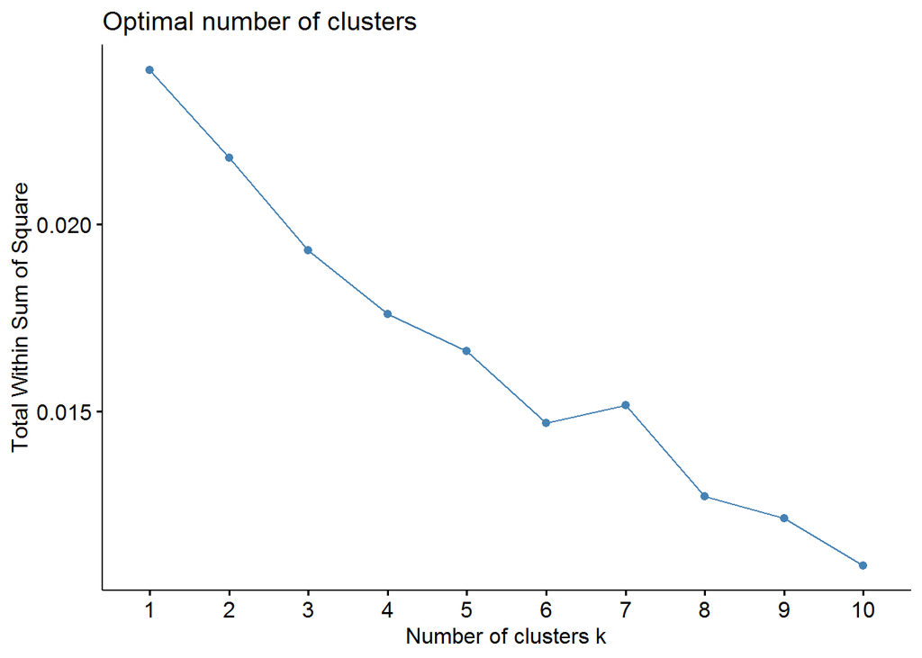

```r
fviz_nbclust(as.matrix(sotu_dfm), kmeans, method = "wss")
```

Visual representation of our k-means

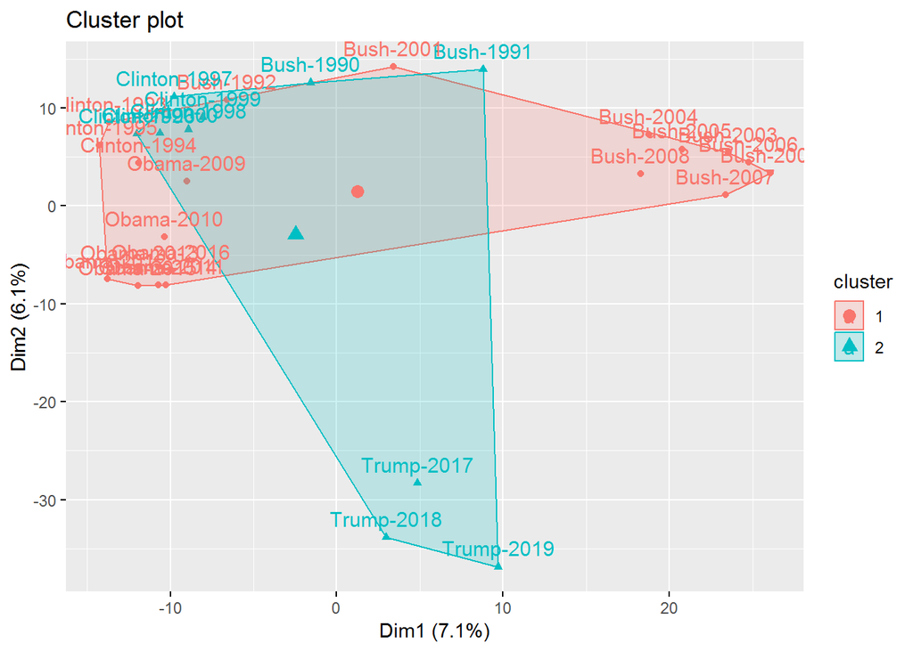

```r
fviz_cluster(sotu_k, data = sotu_dfm)
```

Let’s compare the evolution with different K-s.

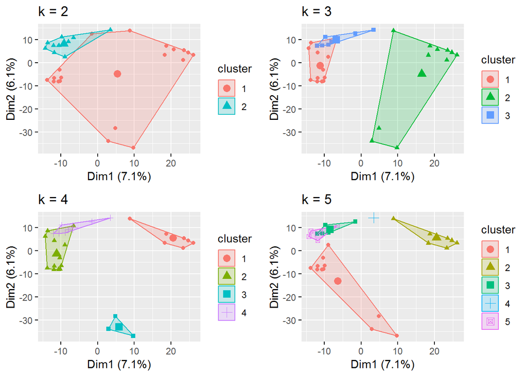

```r
k2 <- kmeans(sotu_dfm, centers = 2)
k3 <- kmeans(sotu_dfm, centers = 3)
k4 <- kmeans(sotu_dfm, centers = 4)
k5 <- kmeans(sotu_dfm, centers = 5)

# plots to compare
p1 <- fviz_cluster(k2, geom = "point", data = sotu_dfm) + ggtitle("k = 2")
p2 <- fviz_cluster(k3, geom = "point",  data = sotu_dfm) + ggtitle("k = 3")
p3 <- fviz_cluster(k4, geom = "point",  data = sotu_dfm) + ggtitle("k = 4")
p4 <- fviz_cluster(k5, geom = "point",  data = sotu_dfm) + ggtitle("k = 5")


gridExtra::grid.arrange(p1, p2, p3, p4, nrow = 2)
```

## 1.3 Hierarchical clustering

The process of hierarchical clustering rests on computing some sort of distance measure and then start our bottom-up aggregation process. IMPORTANT, use some sort of normalization (we did with the `dfm_weight` in the beggining) for the Euclidean distance computation!

```r
sotu_dist_mat <- as.dist(textstat_dist(sotu_dfm, method = "euclidean"))
```

The clustering algorithm is provided by the base R function `hclust`

```r
sotu_hclust <- hclust(sotu_dist_mat, method = "complete")
```

A visual representation with base R

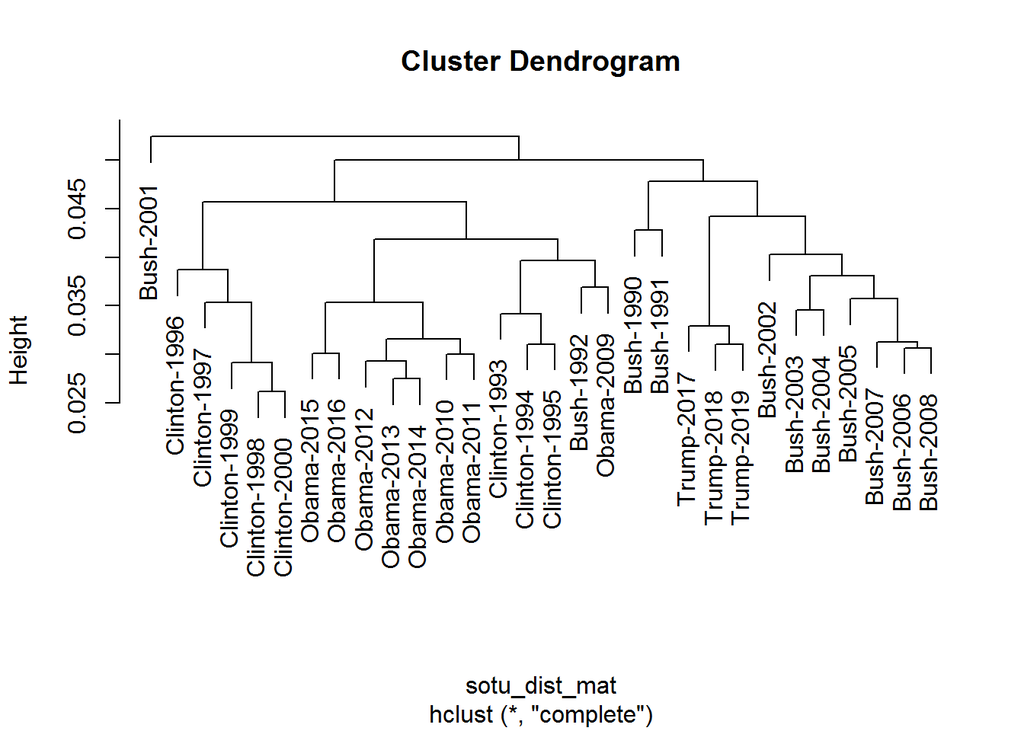

```r
plot(sotu_hclust)
```

A nicer plot can be made with the `ggdendro` package

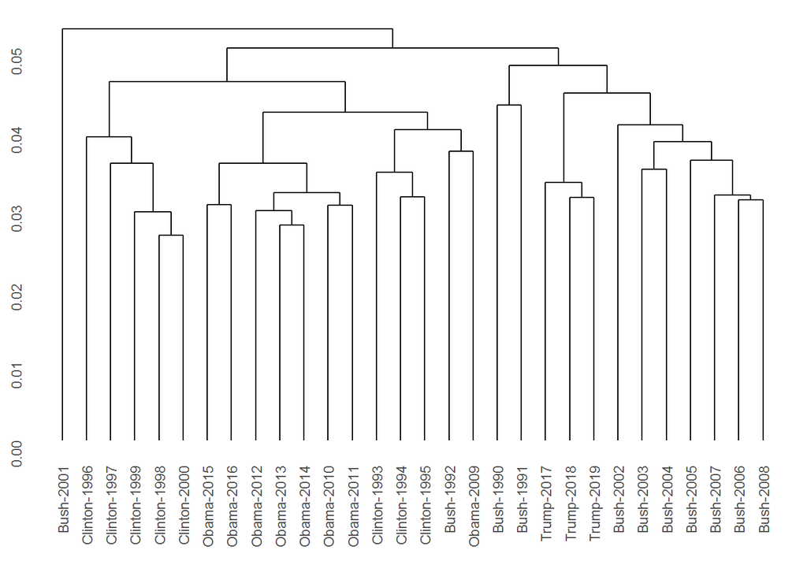

```r
ggdendrogram(sotu_hclust, rotate = FALSE)
```